# opencv - 1

opencv - 컴퓨터 비전 라이브러리  
설치 - pip install opencv-python

영상은 2차원 행렬.  
그레이스케일 영상: 흑백사진이지만 2톤으로 표현된 것이 아니라 밝기 정보를 256단계로 표현  
3줄4칸 이미지:  
[[12,234,123,89],  
[78,54,98,198],  
[12,234,123,89]]

트루컬러 영상: 칼라 영상. r, g, b 각각 256 단계로 표현

3줄4칸 이미지:  
[[[12,234,123],[78,54,98], [234,123,89], [54,98,198]],  
[[78,54,98],[198,234,123,89],[78,54,98], [234,123,89]],  
[[12,234,123],[78,54,98], [234,123,89], [54,98,198]]]

2D image img.shape => (h, w, c)  
h:세로길이 / w:가로길이 / c:색상(b, g, r)

영상 데이터 타입

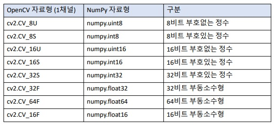

```python
import cv2
```

<영상 생성>

```python
import numpy as np

img1 = np.empty((200, 300), dtype=np.uint8)#그레이스케일 이미지
img2 = np.zeros((200, 300, 3), dtype=np.uint8)#칼라 이미지
img3 = np.ones((200, 300), dtype=np.uint8)*255 #그레이스케일 이미지. 흰바탕
img4 = np.full((200, 300, 3), (0, 255, 255), dtype=np.uint8) #칼라 이미지의 노란바탕

cv2.imshow('img1', img1)
cv2.imshow('img2', img2)
cv2.imshow('img3', img3)
cv2.imshow('img4', img4)

cv2.waitKey(0)   #키보드 입력 대기. 입력한 키값 반환
cv2.destroyAllWindows()  #모든 윈도우 창 닫음
```

<이미지 읽기>  
cv2.imread('파일경로', flag)  
flag - cv2.IMREAD_COLOR: 칼라 이미지. 상수 1  
cv2.IMREAD_GRAYSCALE: 흑백 이미지. 상수 0  
cv2.IMREAD_UNCHANGED: 알파값도 같이 읽음. 상수 -1

<이미지 출력>  
cv2.imshow(title, img)  
title - 제목  
img - 출력할 이미지 값(numpy배열. cv2.imread()의 반환값)

```python
import cv2

fname = 'b.jpg'

original = cv2.imread(fname, cv2.IMREAD_COLOR)
gray = cv2.imread(fname, cv2.IMREAD_GRAYSCALE)
unchange = cv2.imread(fname, cv2.IMREAD_UNCHANGED)

cv2.imshow('Original', original)
cv2.imshow('Gray', gray)
cv2.imshow('Unchange', unchange)

cv2.waitKey(0)   #키보드 입력 대기. 입력한 키값 반환
cv2.destroyAllWindows()  #모든 윈도우 창 닫음
```

```python
original
```

```
array([[[212, 211, 221],
        [208, 207, 217],
        [212, 209, 218],
        ...,
        [125,  95,  76],
        [123,  96,  76],
        [123,  96,  76]],

       [[212, 211, 221],
        [213, 212, 222],
        [224, 220, 231],
        ...,
        [128,  98,  79],
        [127,  97,  78],
        [125,  98,  78]],

       [[229, 229, 241],
        [227, 228, 238],
        [240, 239, 249],
        ...,
        [129,  99,  80],
        [128,  98,  79],
        [128,  98,  79]],

       ...,

       [[ 19,  54,  67],
        [  0,  35,  48],
        [  0,  31,  41],
        ...,
        [ 14,  53,  85],
        [ 25,  61,  91],
        [ 18,  55,  83]],

       [[ 15,  53,  65],
        [ 23,  58,  71],
        [  0,  31,  41],
        ...,
        [ 52,  93, 126],
        [ 42,  80, 112],
        [ 38,  76, 106]],

       [[ 23,  61,  73],
        [ 29,  67,  79],
        [  4,  39,  49],
        ...,
        [ 40,  80, 115],
        [ 35,  73, 107],
        [ 36,  74, 106]]], dtype=uint8)
```

```python
original.shape
```

```
(410, 640, 3)
```

<이미지 쓰기>  
cv2.imwrite('파일명', img)  
img - 저장할 이미지 값(numpy 배열)

```python
import cv2

fname_o = 'b.jpg'
fname_t = 'b_gray.jpg'
gray = cv2.imread(fname_o, cv2.IMREAD_GRAYSCALE)
cv2.imwrite(fname_t,gray)
img = cv2.imread(fname_t)
cv2.imshow('image',img)
cv2.waitKey(0)   #키보드 입력 대기
cv2.destroyAllWindows()  #모든 윈도우 창 닫음
```

matplot에 이미지 출력  
보통 컴퓨터에서 칼라를 표현할때에는 [r,g,b]로 표현하지만 opencv는 [b,g,r]로 표현한다. 그래서 opencv로 읽어들인 이미지를 다른 프로그램을 통해 출력하면 이미지의 색상이 반전되어 출력되므로 출력하기 전 r,g,b를 반전해야 한다.

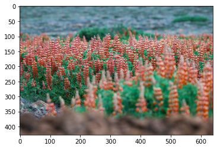

```python
import cv2
from matplotlib import pyplot as plt

img = cv2.imread('a.jpg', cv2.IMREAD_COLOR)
#opencv로 읽은 이미지를 matplot에 그대로 출력. 색상 반전됨
plt.imshow(img)
#plt.xticks([]) # x축 눈금
#plt.yticks([]) # y축 눈금
plt.show()
```

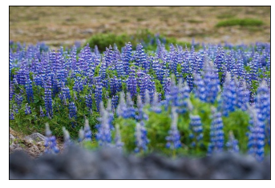

```python
import cv2
from matplotlib import pyplot as plt # as는 alias 적용시 사용

img = cv2.imread('a.jpg', cv2.IMREAD_COLOR)

#opencv로 읽은 이미지의 r,g,b순서를 뒤집어 배열
b, g, r = cv2.split(img)   # img파일을 b,g,r로 분리
img2 = cv2.merge([r,g,b]) # b,,g, r을 바꿔서 Merge

plt.imshow(img2)
plt.xticks([]) # x축 눈금
plt.yticks([]) # y축 눈금
plt.show()
```